# Traffic Data Analysis

```r
library(ggplot2)
library(dplyr)
library(lubridate)
library(gridExtra)
library(tidyr)
```

# 1. Data Reading

```r
df <- read.csv(file="../traffic-data.csv", head=TRUE, sep=",")
```

# 2. Data Preparation

Check for duplicate rows

```r
nrow(df) - nrow(unique(df))
```

```
## [1] 0
```

```r
df <- Filter(function(x)(length(unique(x))>2), df)
ncol(df)
```

```
## [1] 15
```

Check mean of NA in each colmun

```r
na_means = c()
for (i in 1:ncol(df)) {
     na_means  <- c(na_means,  mean(is.na(df[i])))
}
na_means
```

```
##  [1] 0.000000000 0.000000000 0.000000000 0.070002930 0.003504798
##  [6] 0.003504798 0.000000000 0.121063207 0.000000000 0.000000000
## [11] 0.032478104 0.000000000 0.000000000 0.957214488 0.354798573
```

Last two columns have big NA mean. by looking in the dataset it appeas to be images which can be excluded from the anaylsis. So, its okay to remove these two columns

```r
df = subset(df, select = -c(ncol(df), ncol(df)-1) )
ncol(df)
```

```
## [1] 13
```

Check mean of unique values percentage in each colmun

```r
unique_values_percentage = c()
for (i in 1:ncol(df)) {
     val = length(unique(df[i])) / length(df[i])
     unique_values_percentage  <- c(unique_values_percentage,  val)
}
unique_values_percentage
```

```
##  [1] 1 1 1 1 1 1 1 1 1 1 1 1 1
```

After examining the meaning of data, we can get rid of the duplicate rows(have the same comment id)

```r
nrow(df)
```

```
## [1] 429982
```

```r
df <- subset(df, !duplicated(df[,13]))
nrow(df)
```

```
## [1] 148367
```

Change crawl date column into R-data type date

```r
df$crawl_date <- as.POSIXct(df$crawl_date,format = "%a %b  %e %H:%M:%S UTC %Y", tz ="UTC")
```

Normalize the report and road dates

```r
df$crawl_date <- df$crawl_date + hours(2)
df$report_date <-  as.POSIXct(df$crawl_date - (df$rd.rp.hr*60*60) - (df$rd.rp.mn*60))
df$road_date <-  as.POSIXct(df$crawl_date - (df$rd.hr*60*60) - (df$rd.mn*60))
df$rd.rp.hr <-  df$report_date %>% hour()
df$rd.rp.mn <-  df$report_date %>% minute()
df$rd.rp.day <-  df$report_date %>% weekdays()
```

Add columns area, from, to which repreents the main area of the road and the directions

```r
df <- df %>% mutate(rd.nm.tmp = rd.nm)
df <- df %>% separate(col = rd.nm.tmp, into = c('rd.area', 'rd.from.tmp'), sep=';')
df <- df %>% separate(col = rd.from.tmp, into = c('rd.from', 'rd.to'), sep='To')
```

As the web app providing each road’s city, so there is the ability to add the city column to our data. If rd.city = true then it is in cairo.

```r
cairo.roads <- c("Line 1","Line 2","Line 3","Autostrad","Ba7r A3zam","Da2ery","El Wasla","Mansoureya","Faissal St.","Gesr ElSuez","Haram St.","Ismailia Rd.","Ismailia Road","Me7war Sa3d ElShazly","Kobry 15 Mayo","Kobry 3abbas","Kobry 6 October","Ta7t K.October(Lotfy ElSayed)","Ta7t K.October(Mahmasha)","Waslet Kobry 6 October To 15 Mayo","Kobry Kasr ElNile","Kobry ElGam3a","Kornich ElNile","AlKasr Al3eny St.","Kornich Agouza","Nasr st","Zahraa st","Ma3ady","Mostafa ElNa7as","Zaker 7esein","3abbas El3akkad","Makram 3ebeid","Tayaran St.","Madinet Nasr","Khalifa ElMa2moun St.","Marghani St.","Nozha St.","Thawra St.","Masr ElGedeeda","Me7war","Me7war Ahmed 3orabi","Me7war Saft ElLaban","Me7war ElKhalafawy","Me7war ElShaheed","Batal Ahmed St.","Gam3et ElDewal St","Mohandesin","Sudan St.","Tahrir St.","Morad St.","Nafa2 ElAzhar","NA Road","90 St.","Emtedad Ramses","Lotfy ElSayed","Ramses St.","ElGala2","Waslet Pyramids Heights","Sa7rawy","Sala7 Salem","Suez Rd.","Fayoum Rd.","Wahat Road","West ElBalad","Midan ElTa7rir","Zamalek","Zera3y Road","Other Roads","Wadi ElNatron","Sharm Rd")

df$rd.city <- FALSE
df <- df %>% mutate(rd.city = rd.area %in% cairo.roads)
```

# 3 Congestion

## 3.1 Congestion Overview

The proposed metric to check the congestion of a road is to take the average of the status road(7alawa,laziz, mashy,za7ma,mafesh 2amal) in all the reports concerning that road. But to avoid the outliers to affect the results, the congestion value multipled by the weight of that road.

Here are the first 6 area with highst congestion:

```r
crowded_area <- df %>% subset(rd.rp.stid >= 1 & rd.rp.stid <=5 ) %>% group_by(rd.area) %>% summarise(crowded = mean(rd.rp.stid) , count = length(rd.area))
crowded_roads <- df %>% subset(rd.rp.stid >= 1 & rd.rp.stid <=5 ) %>% group_by(rd.nm) %>% summarise(crowded = mean(rd.rp.stid), count = length(rd.nm))

length <- df %>% subset(rd.rp.stid >= 1 & rd.rp.stid <=5 ) %>% nrow()
crowded_area$crowded = crowded_area$crowded * (crowded_area$count/length)
crowded_area <- crowded_area[order(crowded_area$crowded, decreasing = TRUE),]

crowded_roads$crowded = crowded_roads$crowded * (crowded_roads$count/length)
crowded_roads <- crowded_roads[order(crowded_roads$crowded, decreasing = TRUE),]
```

The most crowded areas are:

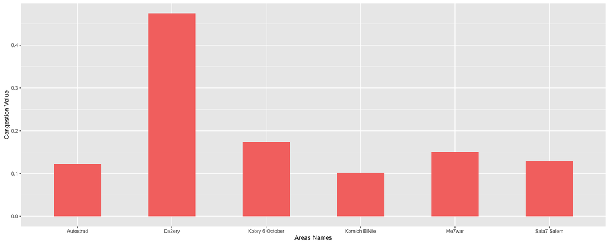

The most croweded roads are:

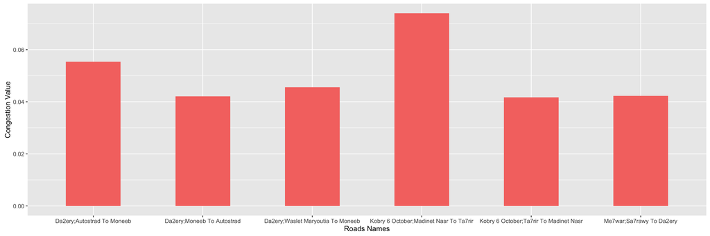

It is resnoable that the rush hour is when the users tend to report more about the roads. So, the proposed metric for the rush hour is to check number of reports each hour.

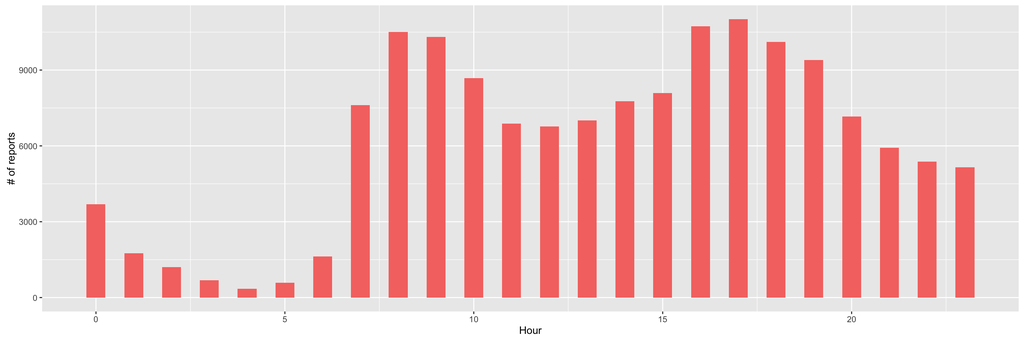

The weekdays congestion

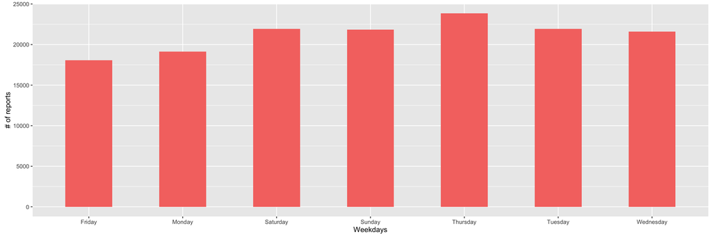

## 3.2 Main areas congestion investigation

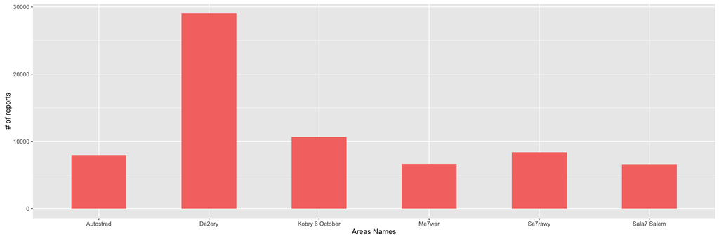

The most croweded segment of the mentioned areas.

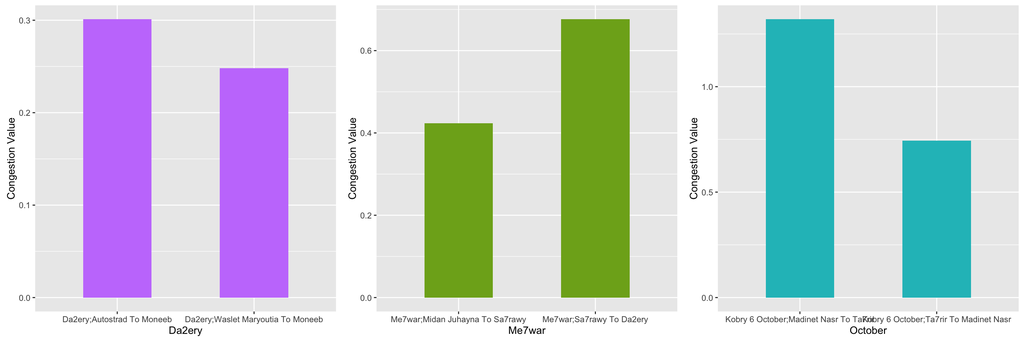

The rush hour of the mentioned areas.

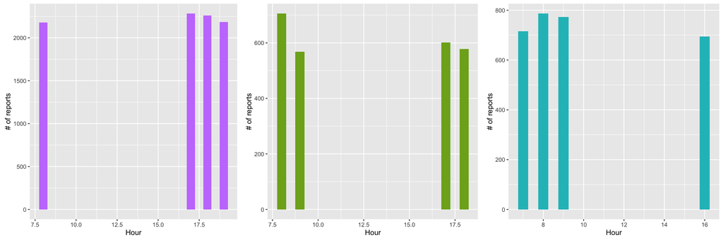

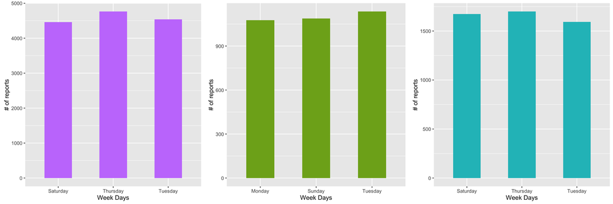

As long we have the the city name for each road. So, we can check which users tend to report about the roads in Cairo and Alex.

```
## Source: local data frame [2 x 2]
##
##   rd.city  count
##     (lgl)  (int)
## 1   FALSE  14772
## 2    TRUE 133595
```

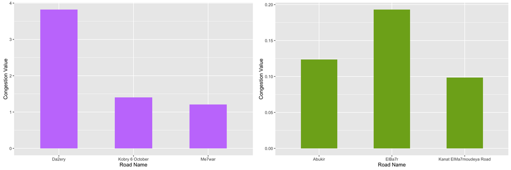